# STAT501 - SLR Model Evaluation

Ada Lazuli

2025-09-04

```r
library(dplyr)
##
## Attaching package: 'dplyr'
## The following objects are masked from 'package:stats':
##
##     filter, lag
## The following objects are masked from 'package:base':
##
##     intersect, setdiff, setequal, union
library(ggplot2)
library(qqplotr)
##
## Attaching package: 'qqplotr'
## The following objects are masked from 'package:ggplot2':
##
##     stat_qq_line, StatQqLine
library(tidyr)
library(reactable)
library(openxlsx)
```

# Confidence Interval with $\beta_1$

We’re given data that contains mortality and latitude of people inflicted with cancer.

The first step is to load the data and render with a scatter plot.

```r
skincancer <- read.table("Data/STAT501_Lesson02/skincancer.txt", header=T)
reactable(skincancer,searchable = TRUE,sortable = TRUE,
          defaultPageSize = 5, bordered = TRUE, highlight = TRUE)
```

| State | Lat | Mort | Ocean | Long |
| --- | --- | --- | --- | --- |
| Alabama | 33 | 219 | 1 | 87 |
| Arizona | 34.5 | 160 | 0 | 112 |
| Arkansas | 35 | 170 | 0 | 92.5 |
| California | 37.5 | 182 | 1 | 119.5 |
| Colorado | 39 | 149 | 0 | 105.5 |
| Connecticut | 41.8 | 159 | 1 | 72.8 |
| Delaware | 39 | 200 | 1 | 75.5 |
| Wash,D.C. | 39 | 177 | 0 | 77 |
| Florida | 28 | 197 | 1 | 82 |
| Georgia | 33 | 214 | 1 | 83.5 |

[output cut: 39 more lines]

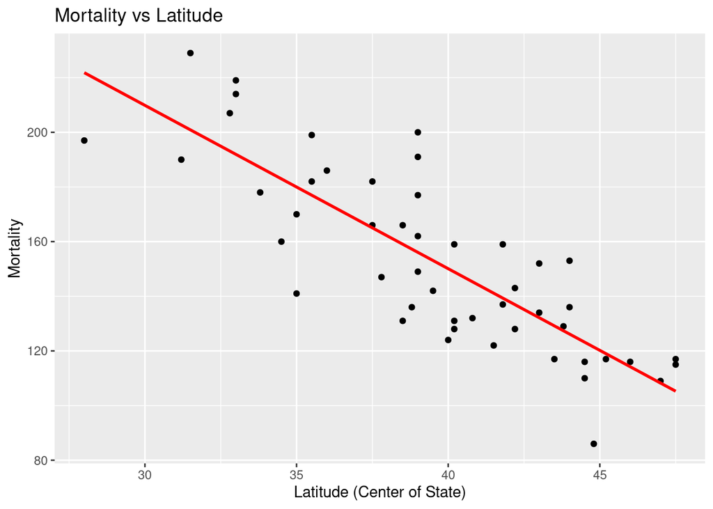

```r
ggplot(skincancer, aes(x = Lat, y = Mort)) + geom_point() +
  geom_smooth(method = "lm", se = FALSE, color = "red") +
  ggtitle("Mortality vs Latitude") + xlab("Latitude (Center of State)") +
  ylab("Mortality")
```

It appears that that mortality decreases *linearly* as latitude increases.

Next, creating the model:

```r
model <- lm(skincancer$Mort ~ skincancer$Lat)
summary(model)
```

```
##
## Call:
## lm(formula = skincancer$Mort ~ skincancer$Lat)
##
## Residuals:
##     Min      1Q  Median      3Q     Max
## -38.972 -13.185   0.972  12.006  43.938
##
## Coefficients:
##                Estimate Std. Error t value Pr(>|t|)
## (Intercept)    389.1894    23.8123   16.34  < 2e-16 ***
## skincancer$Lat  -5.9776     0.5984   -9.99 3.31e-13 ***
## ---
## Signif. codes:  0 '***' 0.001 '**' 0.01 '*' 0.05 '.' 0.1 ' ' 1
##
## Residual standard error: 19.12 on 47 degrees of freedom
## Multiple R-squared:  0.6798, Adjusted R-squared:  0.673
## F-statistic:  99.8 on 1 and 47 DF,  p-value: 3.309e-13
```

The 95% confidence interval is:

```r
confint(model, level=0.95)
```

```
##                     2.5 %     97.5 %
## (Intercept)    341.285151 437.093552
## skincancer$Lat  -7.181404  -4.773867
```

This is interpreted to mean:

> > We are 95% confidence that the population slope is between -7.2 and -4.8. That is, we are 95% confident that for every additional one-degree increase in latitude, the mean skin cancer mortality rate decreases between 4.8 and 7.2 deaths per 10 million people.

# Slope Inference with $\beta_1$

Is there a positive relationship between sales of leaded gasoline and the lead burden in the bodies of newborn infants? Researchers (Rabinowitz, et al, 1984) who were interested in answering this research question compiled data (Lead Cord data) on the monthly gasoline lead sales (in metric tons) in Massachusetts and mean lead concentrations (µl/dl) in umbilical-cord blood of babies born at a major Boston hospital over 14 months in 1980-1981.

```r
cordblood <- read.table("Data/STAT501_Lesson02/leadcord.txt", header=T)
reactable(cordblood,searchable = TRUE,sortable = TRUE,
          defaultPageSize = 5, bordered = TRUE, highlight = TRUE)
```

| Month | Year | Sold | Cord |
| --- | --- | --- | --- |
| 3 | 1980 | 141 | 6.4 |
| 4 | 1980 | 166 | 6.1 |
| 5 | 1980 | 161 | 5.7 |
| 6 | 1980 | 170 | 6.9 |
| 7 | 1980 | 148 | 7 |
| 8 | 1980 | 136 | 7.2 |
| 9 | 1980 | 169 | 6.6 |
| 10 | 1980 | 109 | 5.7 |
| 11 | 1980 | 117 | 5.7 |
| 12 | 1980 | 87 | 5.3 |

[output cut: 4 more lines]

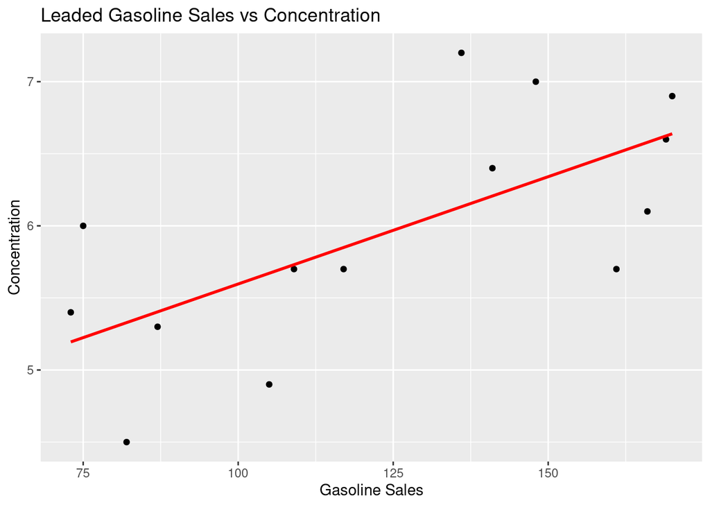

```r
ggplot(cordblood, aes(x = Sold, y = Cord)) + geom_point() +
  geom_smooth(method = "lm", se = FALSE, color = "red") +
  ggtitle("Leaded Gasoline Sales vs Concentration") + xlab("Gasoline Sales") +
  ylab("Concentration")
```

To explore the relationship further, lets do a hypothesis test of on the slope of the regression line.

The hypotheses are for a test as a significance level of 0.05:

1. $H_0: \beta_1 \leq 0$
2. $H_a: \beta_1 > 0$

Next, modeling the data and thing the p-value:

```r
model <- lm(cordblood$Cord ~ cordblood$Sold)
summary(model)
```

```
##
## Call:
## lm(formula = cordblood$Cord ~ cordblood$Sold)
##
## Residuals:
##      Min       1Q   Median       3Q      Max
## -0.82877 -0.39679 -0.02723  0.24729  1.06742
##
## Coefficients:
##                Estimate Std. Error t value Pr(>|t|)
## (Intercept)    4.108182   0.608806   6.748 2.05e-05 ***
## cordblood$Sold 0.014885   0.004719   3.155   0.0083 **
## ---
## Signif. codes:  0 '***' 0.001 '**' 0.01 '*' 0.05 '.' 0.1 ' ' 1
##
## Residual standard error: 0.6162 on 12 degrees of freedom
## Multiple R-squared:  0.4533, Adjusted R-squared:  0.4078
## F-statistic: 9.952 on 1 and 12 DF,  p-value: 0.008303
```

The p-value returned by R is for a two tailed test. so we need to divide it by two for a one-tailed test.

```r
0.0083/2
```

```
## [1] 0.00415
```

> > The researchers can be 95% confident that the mean lead concentrations in the umbilical-cord blood of Massachusetts babies increase between 0.0046 and 0.0252 µl/dl for every one-metric ton increase in monthly gasoline lead sales in Massachusetts. It is up to the researchers to debate whether or not this is a meaningful increase.

# ANOVA

Returning to the skin cancer data for ANOVA.

```r
skincancer <- read.table("Data/STAT501_Lesson02/skincancer.txt", header=T)
model <- lm(skincancer$Mort ~ skincancer$Lat)
anova(model)
```

```
## Analysis of Variance Table
##
## Response: skincancer$Mort
##                Df Sum Sq Mean Sq F value    Pr(>F)
## skincancer$Lat  1  36464   36464  99.797 3.309e-13 ***
## Residuals      47  17173     365
## ---
## Signif. codes:  0 '***' 0.001 '**' 0.01 '*' 0.05 '.' 0.1 ' ' 1
```

Are does not calculate SSTO by default. This code extracts is from the anova summary.

```r
a <- anova(model)
sse <- a["Residuals", "Sum Sq"]
ssr <- sum(a[1, "Sum Sq"])
ssto <- sse + ssr
ssto
```

```
## [1] 53637.27
```

# Dual T-Test and ANOVA

This example with data taht contains height and GPA.

```r
heightgpa <- read.table("Data/STAT501_Lesson02/heightgpa.txt", header=T)
reactable(heightgpa,searchable = TRUE,sortable = TRUE,
          defaultPageSize = 5, bordered = TRUE, highlight = TRUE)
```

| height | gpa |
| --- | --- |
| 66 | 2.9 |
| 57 | 3.16 |
| 64.5 | 3.62 |
| 62 | 2 |
| 69.5 | 3.45 |
| 65 | 2.8 |
| 63 | 3.63 |
| 68 | 2.81 |
| 59.5 | 3.33 |
| 64 | 2.75 |

[output cut: 25 more lines]

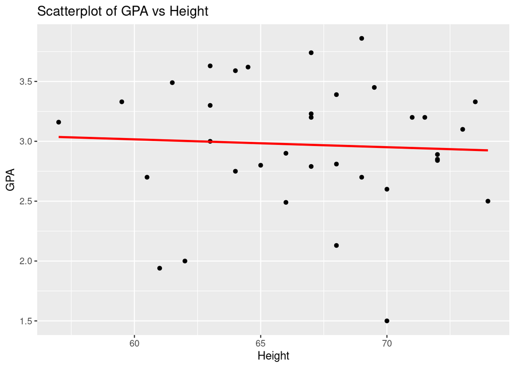

```r
ggplot(heightgpa, aes(x = height, y = gpa)) + geom_point() +
  geom_smooth(method = "lm", se = FALSE, color = "red") +
  ggtitle("Scatterplot of GPA vs Height") + xlab("Height") +
  ylab("GPA")
```

It appears that there not a linear relationship between GPA and height.

To confirm this, we’ll use both a t-test and ANOVA.

The hypotheses are for a test as a significance level of 0.05:

1. $H_0: \beta_1 = 0$
2. $H_a: \beta_1 \neq 0$

```r
model <- lm(heightgpa$gpa ~ heightgpa$height)
summary(model)
```

```
##
## Call:
## lm(formula = heightgpa$gpa ~ heightgpa$height)
##
## Residuals:
##      Min       1Q   Median       3Q      Max
## -1.45081 -0.24878  0.00325  0.35622  0.90263
##
## Coefficients:
##                   Estimate Std. Error t value Pr(>|t|)
## (Intercept)       3.410214   1.434616   2.377   0.0234 *
## heightgpa$height -0.006563   0.021428  -0.306   0.7613
## ---
## Signif. codes:  0 '***' 0.001 '**' 0.01 '*' 0.05 '.' 0.1 ' ' 1
##
## Residual standard error: 0.5423 on 33 degrees of freedom
## Multiple R-squared:  0.002835,   Adjusted R-squared:  -0.02738
## F-statistic: 0.09381 on 1 and 33 DF,  p-value: 0.7613
```

The p-value from the t-test for height is 0.7613.

```r
anova(model)
```

```
## Analysis of Variance Table
##
## Response: heightgpa$gpa
##                  Df Sum Sq Mean Sq F value Pr(>F)
## heightgpa$height  1 0.0276 0.02759  0.0938 0.7613
## Residuals        33 9.7055 0.29411
```

Similarly, the p-value from the f-test is also 0.7613

Therefore, there is insufficient statistical evidence to conclude that there is a linear relationship between height and grade point average.